# Задание 6 (Контрольные вопросы)

## Тема: Введение в статистический анализ данных

### Настройка окружения

```python
import pandas as pd
import numpy as np
import matplotlib.pyplot as plt
```

### 1. Что такое статистика? Примеры использования статистики в реальной жизни.

**Статистика** — это набор математических процедур, которые необходимы для организации, обобщения и интерпретации информации.

*Примеры использования:*

- **Анализ рыночных данных в бизнесе**: прогнозирование спроса, анализ потребительского поведения, оптимизация ценовой политики.
- **Оценка демографических показателей**: анализ численности населения, структуры возрастных групп, миграции.
- **Медицинские исследования**: изучение эффективности лекарств, анализ распространения заболеваний, статистика смертности и заболеваемости.

### 2. Типы признаков: количественные и качественные.

1. Количественные данные выражаются числами, которые имеют математическое значение (рост, вес, зарплата). Такие данные можно сравнивать друг с другом.

   Существует два подтипа количественных данных:
   - **Интервальные данные**. Нулевое значение выбирается произвольно для удобства. Например, температура по Цельсию и по Фаренгейту.
   - **Данные, измеренные по шкале отношений**. Нулевое значение определяется однозначно. Например, количество товара на складе.

   Также количественные данные можно разделить на две других подгруппы:
   - **Дискретные**
   - **Непрерывные**
2. Качественные данные отражают принадлежность к категориям.

   Существует два подтипа качественных данных:
   - **Порядковые**. Их можно упорядочить. Например, степень ожога.
   - **Номинальные**. Нельзя упорядочить. Например, породы кошек.

### 3. Количественные данные: интервальные данные и данные, измеренные по шкале отношений.

Количественные данные выражаются числами, которые имеют математическое значение (рост, вес, зарплата). Такие данные можно сравнивать друг с другом.

1. **Интервальные данные**. Нулевое значение выбирается произвольно для удобства
   - pH-уровень раствора (0 pH не означает отсутствия кислотности, это просто граница шкалы);
   - Год рождения (разница между 1990 и 2000 годом имеет смысл, но "нулевой" год в календаре условный).
2. **Данные, измеренные по шкале отношений**. Нулевое значение определяется однозначно.
   - Расход топлива автомобиля в литрах (0 литров — значит топлива нет);
   - Время в секундах (0 секунд — это полное отсутствие продолжительности события).

### 4. Количественные данные: непрерывные и дискретные.

1. **Дискретные**. Принимают только конкретные (целые) значения, не могут быть дробными.
   - Количество детей в семье;
   - Число автомобилей на парковке;
   - Количество экзаменов.
2. **Непрерывные**. Могут принимать любые значения в пределах диапазона, в том числе дробные.
   - Время бега на 100 метров;
   - Средний балл в классе (по 5-балльной шкале);
   - Температура на улице.

### 5. Качественные данные: порядковые и номинальные.

1. **Порядковые**. Категории можно упорядочить.
   - Размер одежды (S, M, L, XL);
   - Уровень прожарки мяса (Extra Rare, Rare, Medium Rare, Medium Well);
   - Воинские звания (рядовой, сержант, лейтенант, капитан, майор).
2. **Номинальные**. Категории без четкого порядка.
   - Цвет глаз (синий, карий, зеленый);
   - Гражданство (Росии, Германии, Франции, США);
   - Виды джинсов (Клеш, скинни, мом, широкие).

### 6. Что такое генеральная совокупность?

**Генеральная совокупность** — это совокупность всех объектов, которые представляют интерес в конкретном исследовании.

*Примеры:*

- Все студенты в городе;
- Все пациенты с диабетом в стране.

### 7. Что такое выборка?

**Выборка** — это группа объектов, отобранных из генеральной совокупности для исследования.

*Примеры:*

- Часть студентов, которых отобрали для измерения роста;
- 200 пациентов, принявших участие в исследовании.

### 8. Репрезентативность выборки. Смещение.

**Репрезентативность** — соответствие характеристик выборки характеристикам генеральной совокупности.

**Смещение выборки** — явление, при котором статистические характеристики выборки сильно отличаются (смещены) относительно характеристик генеральной совокупности.

### 9. Визуализация частотного распределения с помощью гистограммы, полигона и столбчатой диаграммы.

```python
np.random.seed(42)
```

**Гистограмма** показывает распределение количественных данных, группируя их в интервалы.

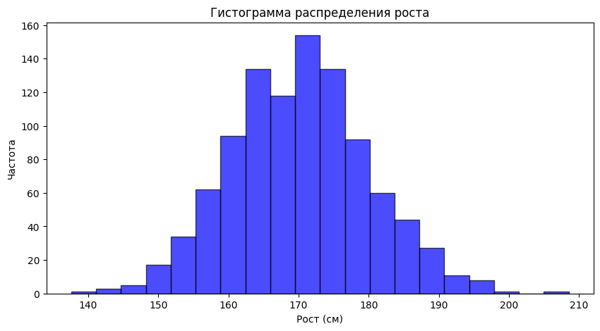

```python
data_hist = np.random.normal(loc=170, scale=10, size=1000)

plt.figure(figsize=(10, 5))
plt.hist(data_hist, bins=20, color="blue", alpha=0.7, edgecolor="black")
plt.title("Гистограмма распределения роста")
plt.xlabel("Рост (см)")
plt.ylabel("Частота")
plt.show()
```

**Полигон частот** похож на гистограмму, но вместо столбцов используются точки, соединённые линиями.

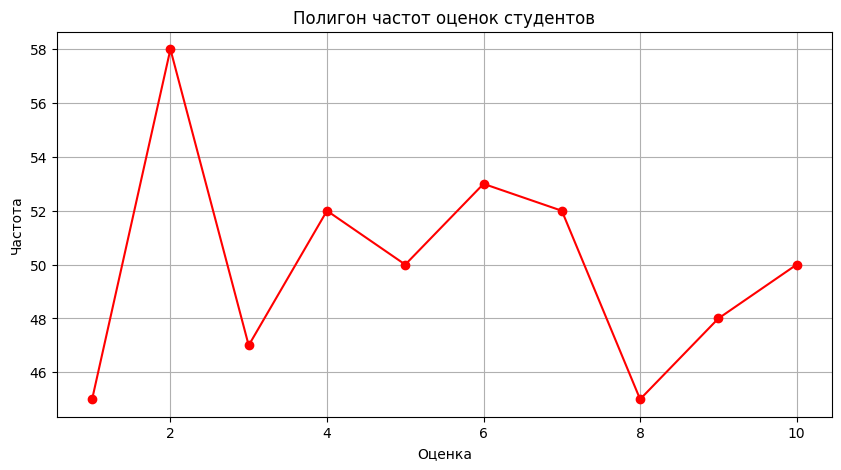

```python
data_polygon = np.random.randint(1, 11, size=500)

plt.figure(figsize=(10, 5))
values, counts = np.unique(data_polygon, return_counts=True)
plt.plot(values, counts, marker="o", linestyle="-", color="red")
plt.title("Полигон частот оценок студентов")
plt.xlabel("Оценка")
plt.ylabel("Частота")
plt.grid()
plt.show()
```

Аналогом гистограммы для качественных данных является **столбчатая диаграмма**. Для ее построения нужны ровно те же действия, что и для гистограммы, но визуально она немного отличается: между столбцами для разных категорий есть расстояние.

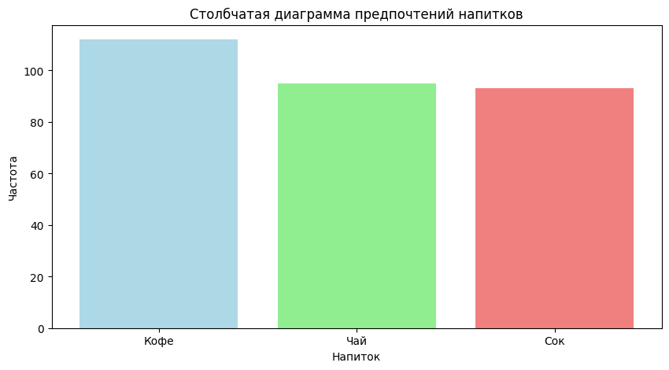

```python
categories = ["Кофе", "Чай", "Сок"]

data_bar = pd.Series(np.random.choice(categories, size=300))
data_freq = data_bar.value_counts()

plt.figure(figsize=(10, 5))
plt.bar(
    data_freq.index, data_freq.values, color=["lightblue", "lightgreen", "lightcoral"]
)
plt.title("Столбчатая диаграмма предпочтений напитков")
plt.xlabel("Напиток")
plt.ylabel("Частота")
plt.show()
```

### 10. Что такое случайная величина (СВ)?

**Случайная величина (СВ)** — это величина, значение которой зависит от случайных обстоятельств, то есть она может принимать различные значения с определённой вероятностью. Случайная величина является числовым отображением исходов случайного эксперимента.

В зависимости от множества возможных значений, случайные величины делятся на дискретные и непрерывные.

- **Дискретная случайная величина** может принимать только конечное или счётное множество отдельных значений. Например, число очков, выпавших при подбрасывании игральной кости. Возможные значения: все числа от 1 до 6 с одинаковой вероятностью.
- **Непрерывная случайная величина** может принимать любые значения из некоторого интервала, и их количество — бесконечно. Например, точность, с которой решается оптимизационная задача.

### 11. Что такое закон распределения СВ?

**Закон распределения случайной величины** — это правило, которое описывает, как распределяются вероятности на возможные значения случайной величины. Он показывает, с какой вероятностью случайная величина примет каждое из возможных значений (для дискретной СВ) или попадёт в какой-либо интервал значений (для непрерывной СВ).

### 12. Числовые характеристики дискретных СВ.

1. **Математическое ожидание дискретной случайной величины *X*** — это взвешенная сумма всех возможных значений величины, умноженных на их соответствующие вероятности. Оно отражает среднее значение случайной величины, если бы эксперимент повторялся бесконечно много раз;
2. **Дисперсия** измеряет, насколько значения случайной величины отклоняются от её математического ожидания. Это среднее значение квадрата отклонений от среднего значения.
3. **Стандартное отклонение** - это корень из дисперсии. Оно также отражает, насколько широко распределены значения случайной величины относительно её среднего значения.

### 13. Функция распределения СВ, свойства.

**Функция распределения случайной величины (СВ)** — это функция, которая показывает вероятность того, что случайная величина *X* примет значение, меньшее или равное некоторому заданному числу *x*. Она описывает весь закон распределения случайной величины.

### 14. Функция плотности вероятности непрерывной СВ, свойства.

**Функция плотности вероятности (ПВ)** — это функция, которая описывает вероятность того, что непрерывная случайная величина *X* примет значение, находящееся в определённом интервале. В отличие от дискретных случайных величин, для которых вероятность того, что случайная величина примет конкретное значение, равна нулю, для непрерывных СВ мы говорим о вероятности попадания в интервал.

### 15. Числовые характеристики непрерывных случайных величин.

1. Математическое ожидание
2. Дисперсия
3. Стандартное отклонение

### 16. Задание

Смоделировать 5 выборок объемом 1000 элементов из разных законов распределения: нормальное, экспоненциальное, равномерное и два любых других закона распределения на выбор (см. Генераторы распределений). Визуализировать полученные выборки, используя гистограммы и диаграммы «Ящик с усами», построить эмпирические функцию и плотность распределения. Для каждой выборки посчитать описательные характеристики (минимум и максимум, мат. ожидание, дисперсия, стандартное отклонение, квантили уровней 0.25 и 0.75, размах, медиана, коэффициенты асимметрии и эксцесса).

Генерация выборок

```python
np.random.seed(42)

sample_normal = np.random.normal(loc=0, scale=1, size=1000)
sample_exponential = np.random.exponential(scale=1, size=1000)
sample_uniform = np.random.uniform(low=0, high=1, size=1000)
sample_poisson = np.random.poisson(lam=5, size=1000)
sample_chisquare = np.random.chisquare(df=2, size=1000)

samples = {
    "Нормальное распределение": sample_normal,
    "Экспоненциальное распределение": sample_exponential,
    "Равномерное распределение": sample_uniform,
    "Распределение Пуассона": sample_poisson,
    "Распределение Хи-квадрат": sample_chisquare,
}
```

Визуализация выборок c помощью гистограмм

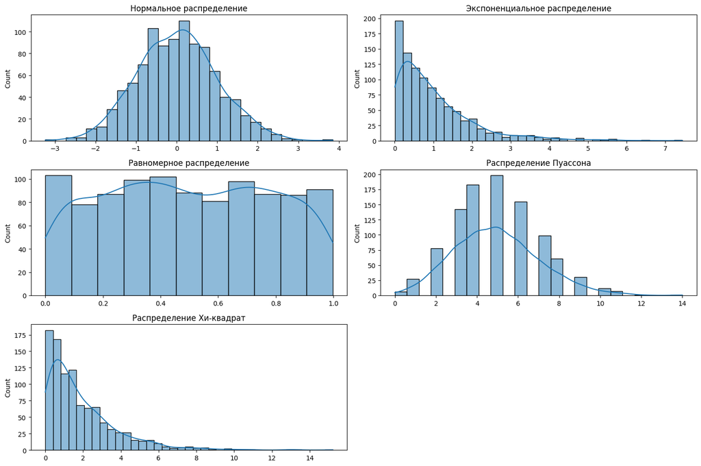

```python
import seaborn as sns

plt.figure(figsize=(15, 10))

for i, (name, sample) in enumerate(samples.items(), 1):
    plt.subplot(3, 2, i)
    sns.histplot(sample, kde=True)
    plt.title(name)

plt.tight_layout()
plt.show()
```

Визуализация выборок c помощью диаграммы "Ящик с усами"

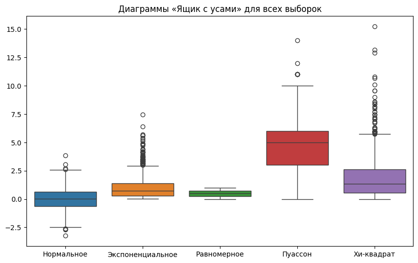

```python
plt.figure(figsize=(10, 6))

sns.boxplot(data=list(samples.values()))

plt.xticks(
    ticks=range(len(samples)),
    labels=["Нормальное", "Экспоненциальное", "Равномерное", "Пуассон", "Хи-квадрат"],
)
plt.title("Диаграммы «Ящик с усами» для всех выборок")
plt.show()
```

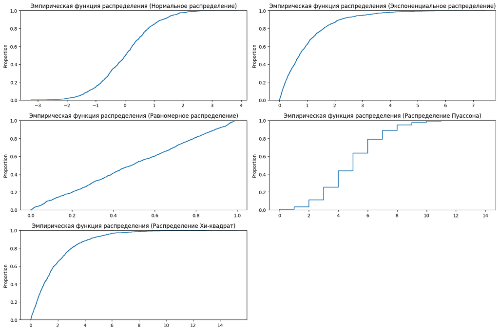

```python
plt.figure(figsize=(15, 10))

for i, (name, sample) in enumerate(samples.items(), 1):
    plt.subplot(3, 2, i)
    sns.ecdfplot(sample)
    plt.title(f"Эмпирическая функция распределения ({name})")

plt.tight_layout()
plt.show()
```

Расчет описательных характеристик

```python
from scipy import stats


def calculate_statistics(sample, name):
    print(f"Описательные характеристики для {name}:")
    print(f"Минимум: {np.min(sample)}")
    print(f"Максимум: {np.max(sample)}")
    print(f"Математическое ожидание: {np.mean(sample)}")
    print(f"Дисперсия: {np.var(sample)}")
    print(f"Стандартное отклонение: {np.std(sample)}")
    print(f"Квантиль 0.25: {np.quantile(sample, 0.25)}")
    print(f"Квантиль 0.75: {np.quantile(sample, 0.75)}")
    print(f"Размах: {np.ptp(sample)}")
    print(f"Медиана: {np.median(sample)}")
    print(f"Коэффициент асимметрии: {stats.skew(sample)}")
    print(f"Коэффициент эксцесса: {stats.kurtosis(sample)}")


for name, sample in samples.items():
    calculate_statistics(sample, name)
    print("\n")
```

```
Описательные характеристики для Нормальное распределение:
Минимум: -3.2412673400690726
Максимум: 3.8527314906547208
Математическое ожидание: 0.019332055822325486
Дисперсия: 0.9579049897315173
Стандартное отклонение: 0.9787262077473543
Квантиль 0.25: -0.6475903054623517
Квантиль 0.75: 0.6479438754729301
Размах: 7.093998830723793
Медиана: 0.02530061223488824
Коэффициент асимметрии: 0.1168008311053351
Коэффициент эксцесса: 0.06620589292148393


Описательные характеристики для Экспоненциальное распределение:
Минимум: 0.003223453352234625
Максимум: 7.4417229097044055
Математическое ожидание: 1.0079859336968675
Дисперсия: 1.00497996320746
Стандартное отклонение: 1.0024868892945484
Квантиль 0.25: 0.28395451688075696
Квантиль 0.75: 1.3716842530660367
Размах: 7.4384994563521705
Медиана: 0.7259312206849301
Коэффициент асимметрии: 1.9808119458203124
Коэффициент эксцесса: 5.379440485395413


Описательные характеристики для Равномерное распределение:
Минимум: 1.1634755366141114e-05
Максимум: 0.9978208556819782
Математическое ожидание: 0.4944949862025107
Дисперсия: 0.08339110152832671
Стандартное отклонение: 0.28877517470919606
Квантиль 0.25: 0.25652351113097016
Квантиль 0.75: 0.7386288812808897
Размах: 0.9978092209266121
Медиана: 0.49171060469217354
Коэффициент асимметрии: 0.009550612027921292
Коэффициент эксцесса: -1.1804114001931738
```

[output cut: 13 more lines]

```
Коэффициент эксцесса: 0.2634494036084196


Описательные характеристики для Распределение Хи-квадрат:
Минимум: 0.00048180706558510083
Максимум: 15.222672236765632
Математическое ожидание: 1.8983768534752876
Дисперсия: 3.563110983352897
Стандартное отклонение: 1.8876204553227582
Квантиль 0.25: 0.5551020361697443
Квантиль 0.75: 2.6328453750454246
Размах: 15.222190429700047
Медиана: 1.3576151821480686
Коэффициент асимметрии: 2.0918780194893865
Коэффициент эксцесса: 6.748372050367106
```

#### Экспорт в html

```python
from os import system

system("jupyter nbconvert --to html task_6.ipynb")
```

```
[NbConvertApp] Converting notebook task_6.ipynb to html
[NbConvertApp] WARNING | Alternative text is missing on 6 image(s).
[NbConvertApp] Writing 707997 bytes to task_6.html
```

```
0
```